# Applied Regression Data Analysis #1

Benjamin Panny

Due January 25th, 2023

# Load Libraries and Data

```r
library(tidyverse)
source("alr_utility.R")
dat <- read_csv("DA4.csv") %>% mutate(race = factor(race, levels=c(1,2), labels=c("white","black")),
                                      dpros = factor(dpros, levels=1:4, labels=c("no nodule","left","right","bilobar")),
                                      dcaps = factor(dcaps, levels=1:2, labels=c("no","yes")))
```

# Background

Question: A study was designed to identify variables associated with tumor penetration of prostatic capsule in patients with prostate cancer. Data were collected from an academic affiliated cancer center. For this assignment, the dataset was modified to include 374 patients and a subset of variables from the main study. Of the 374 patients, 151 had a cancer that penetrated the prostatic capsule.

# Centering Variables

1. For interpretability, center the continuous predictors “age”, “psa”, “vol”, and “gleason” by their median values. Please generate variables “age_c”, “psa_c”, “vol_c” and “gleason_c” accordingly.

```r
dat <- dat %>% mutate(age_c = age - median(age),
               psa_c = psa - median(psa),
               vol_c = vol - median(vol),
               gleason_c = gleason - median(gleason))
```

# Fit 7 candidate models

Model Covariates Deviance Pseudo R-square Adj Pseudo R-square AIC BIC 1 dpros, gleason_c, psa_c  
2 dpros, gleason_c, psa_c dcap  
3 dpros, gleason_c, psa_c, vol_c  
4 dpros, gleason_c, psa_c age_c  
5 dpros, gleason_c, psa_c race  
6 dpros, gleason_c, psa_c, vol_c, race  
7 dpros, gleason_c, pas_c, dcaps, vol_c, age_c, race

```r
glm_1 <- glm(capsule ~ dpros + gleason_c + psa_c, data = dat, family = "binomial")
glm_2 <- glm(capsule ~ dpros + gleason_c + psa_c + dcaps, data = dat, family = "binomial")
glm_3 <- glm(capsule ~ dpros + gleason_c + psa_c + vol_c, data = dat, family = "binomial")
glm_4 <- glm(capsule ~ dpros + gleason_c + psa_c + age_c, data = dat, family = "binomial")
glm_5 <- glm(capsule ~ dpros + gleason_c + psa_c + race, data = dat, family = "binomial")
glm_6 <- glm(capsule ~ dpros + gleason_c + psa_c + vol_c + race, data = dat, family = "binomial")
glm_7 <- glm(capsule ~ dpros + gleason_c + psa_c + dcaps + vol_c + age_c + race, data = dat, family = "binomial")
```

```r
tab <- tribble(~ Model, ~Covariates, ~Deviance, ~`Pseudo R2`, ~`adj Pseudo R2`, ~AIC, ~BIC,
               1, str_c(colnames(glm_1$model)[-1], collapse = ", "),
               deviance(glm_1), DescTools::PseudoR2(glm_1, which="McFadden"), DescTools::PseudoR2(glm_1, which="McFaddenAdj"), AIC(glm_1), BIC(glm_1),
               2, str_c(colnames(glm_2$model)[-1], collapse = ", "),
               deviance(glm_2), DescTools::PseudoR2(glm_2, which="McFadden"), DescTools::PseudoR2(glm_2, which="McFaddenAdj"), AIC(glm_2), BIC(glm_2),
               3, str_c(colnames(glm_3$model)[-1], collapse = ", "),
               deviance(glm_3), DescTools::PseudoR2(glm_3, which="McFadden"), DescTools::PseudoR2(glm_3, which="McFaddenAdj"), AIC(glm_3), BIC(glm_3),
               4, str_c(colnames(glm_4$model)[-1], collapse = ", "),
               deviance(glm_4), DescTools::PseudoR2(glm_4, which="McFadden"), DescTools::PseudoR2(glm_4, which="McFaddenAdj"), AIC(glm_4), BIC(glm_4),
               5, str_c(colnames(glm_5$model)[-1], collapse = ", "),
               deviance(glm_5), DescTools::PseudoR2(glm_5, which="McFadden"), DescTools::PseudoR2(glm_5, which="McFaddenAdj"), AIC(glm_5), BIC(glm_5),
               6, str_c(colnames(glm_6$model)[-1], collapse = ", "),
               deviance(glm_6), DescTools::PseudoR2(glm_6, which="McFadden"), DescTools::PseudoR2(glm_6, which="McFaddenAdj"), AIC(glm_6), BIC(glm_6),
               7, str_c(colnames(glm_7$model)[-1], collapse = ", "),
               deviance(glm_7), DescTools::PseudoR2(glm_7, which="McFadden"), DescTools::PseudoR2(glm_7, which="McFaddenAdj"), AIC(glm_7), BIC(glm_7),)

tab %>%
  mutate(across(where(is.numeric), ~signif(., digits = 4))) %>%
  knitr::kable(.) %>% kableExtra::kable_styling(latex_options = "striped")
```

| Model | Covariates | Deviance | Pseudo R2 | adj Pseudo R2 | AIC | BIC |
| --- | --- | --- | --- | --- | --- | --- |
| 1 | dpros, gleason_c, psa_c | 381.1 | 0.2446 | 0.2208 | 393.1 | 416.7 |
| 2 | dpros, gleason_c, psa_c, dcaps | 379.7 | 0.2474 | 0.2197 | 393.7 | 421.2 |
| 3 | dpros, gleason_c, psa_c, vol_c | 377.7 | 0.2514 | 0.2236 | 391.7 | 419.2 |
| 4 | dpros, gleason_c, psa_c, age_c | 380.6 | 0.2456 | 0.2178 | 394.6 | 422.1 |
| 5 | dpros, gleason_c, psa_c, race | 379.0 | 0.2488 | 0.2211 | 393.0 | 420.5 |
| 6 | dpros, gleason_c, psa_c, vol_c, race | 376.0 | 0.2547 | 0.2230 | 392.0 | 423.4 |
| 7 | dpros, gleason_c, psa_c, dcaps, vol_c, age_c, race | 374.5 | 0.2577 | 0.2180 | 394.5 | 433.8 |

# Pick the “best” model

3. What is the “best” model among the 7 candidate models listed in part b? If candidate models are nested, please use a likelihood ratio test to test the importance of the extra term(s). Justify your choice of a “best” model.

```r
anova(glm_1, glm_3, test="LRT")
```

```
## Analysis of Deviance Table
##
## Model 1: capsule ~ dpros + gleason_c + psa_c
## Model 2: capsule ~ dpros + gleason_c + psa_c + vol_c
##   Resid. Df Resid. Dev Df Deviance Pr(>Chi)
## 1       368     381.12
## 2       367     377.71  1   3.4098  0.06481 .
## ---
## Signif. codes:  0 '***' 0.001 '**' 0.01 '*' 0.05 '.' 0.1 ' ' 1
```

# Probability of tumor penetration

4. Based on the model you identified in part c, estimate the probability of having tumor penetration for a 65-year-old white man who had unilobar nodule (left), but no capsular involvement detected in digital rectal exam, and had 1.4 mg/ml prostatic specific antigen, a 0 cm3 tumor, and total Gleason score of 6.

```r
new_dat <- tibble(gleason_c = 6 - median(dat$gleason), dpros="left", psa_c = 1.4 - median(dat$psa))
predict(glm_1, newdata=new_dat, type = "response")
```

```
##         1
## 0.2040707
```

The probability of this patient having tumor penetration according to model 1 is 0.2041

# Interpret coefficient estimates

5. Interpret the coefficient estimates (Intercept, one categorical and one continuous variables of your choice)

The intercept is the log odds of a patient having tumor penetration if they have a median Gleason score, median prostatic specific antigen level, and “no nodule” for the `dpros` variable. The coefficient for `dprosleft` indicates that when a patient has a left unilobar nodule, there log odds for tumor penetration is .76859 higher than the log odds of a patient with no nodule having tumor penetration. The coefficient for `gleason_c` indicates that for each 1 unit difference away from the median Gleason score, the log odds of a patient having tumor penetration changes by .99354. The log odds decreases for unit changes below the median and the log odds increases for unit changes above the median.

# Test overall model fit

6. Test the overall model fit.

```r
performance::performance_hosmer(glm_1, n_bins = 10)
```

```
## # Hosmer-Lemeshow Goodness-of-Fit Test
##
##   Chi-squared: 9.995
##            df: 8
##       p-value: 0.265
```

```
## Summary: model seems to fit well.
```

There is no evidence to suggest poor fitting.

# Check for residual outliers

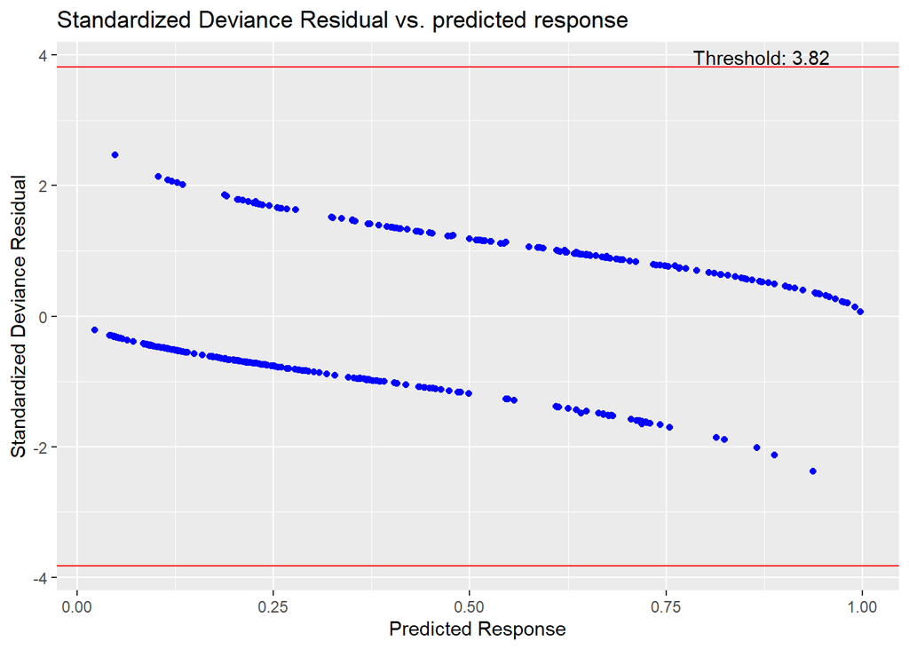

```r
alr_plot_residual(glm_1, x="predicted")
```

There are no residual outliers according to the 3.82 standard deviance threshold.

# Check for high leverage

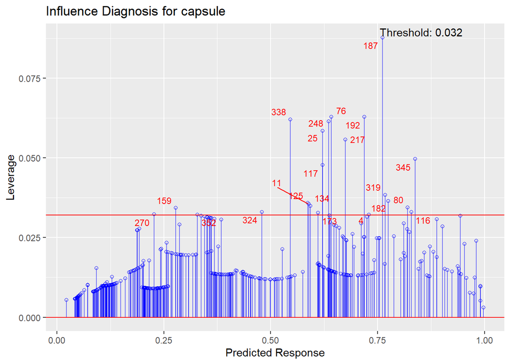

```r
alr_plot_leverage(glm_1, x="predicted", label=dat$id)
```

There are 22 patient IDs with high leverage

```r
(high_leverage <- alr_high_leverage(glm_1, show_leverage = TRUE, label=dat$id, label_name="patient"))
```

```
## # A tibble: 22 × 2
##    patient leverage
##      <dbl>    <dbl>
##  1       4   0.0322
##  2      11   0.0355
##  3      25   0.0584
##  4      76   0.0628
##  5      80   0.0345
##  6     116   0.0331
##  7     117   0.0477
##  8     125   0.0358
##  9     134   0.0349
## 10     159   0.0343
## # … with 12 more rows
```

# Identify high influence patients

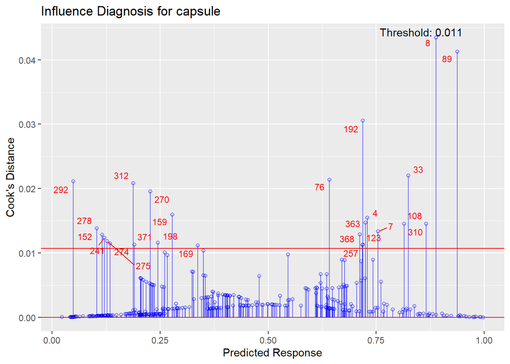

```r
alr_plot_cookd(glm_1, x="predicted", label=dat$id)
```

25 patients have big influence on parameter estimation in model 1.

```r
(high_influence <-  alr_influential_cookd(glm_1, show_cookd = TRUE, label=dat$id, label_name="patient"))
```

```
## # A tibble: 25 × 2
##    patient  cookd
##      <dbl>  <dbl>
##  1       4 0.0155
##  2       7 0.0133
##  3       8 0.0435
##  4      33 0.0220
##  5      76 0.0213
##  6      89 0.0412
##  7     108 0.0145
##  8     123 0.0113
##  9     152 0.0128
## 10     159 0.0159
## # … with 15 more rows
```

# Problematic data points and Goodness of Model Fit

10. Do you have problematic points based on your responses to (b). – (i).? Does your model fit well?

```r
possible_removal <- high_influence %>% full_join(high_leverage, by="patient") %>% drop_na()

possible_removal %>%
  knitr::kable(caption = "Observations For Possible Removal") %>%
  kableExtra::kable_styling(latex_options = "striped")
```

Observations For Possible Removal

| patient | cookd | leverage |
| --- | --- | --- |
| 4 | 0.0154623 | 0.0321840 |
| 76 | 0.0213494 | 0.0628266 |
| 159 | 0.0159247 | 0.0343004 |
| 192 | 0.0305370 | 0.0628147 |
| 270 | 0.0195476 | 0.0322658 |

Data points from 5 patients have both high leverage and high influence over parameter estimation, making them the most problematic points in this sample.

```r
tab %>%
  mutate(across(where(is.numeric), ~signif(., digits = 4))) %>%
  knitr::kable(.) %>% kableExtra::kable_styling(latex_options = "striped")
```

| Model | Covariates | Deviance | Pseudo R2 | adj Pseudo R2 | AIC | BIC |
| --- | --- | --- | --- | --- | --- | --- |
| 1 | dpros, gleason_c, psa_c | 381.1 | 0.2446 | 0.2208 | 393.1 | 416.7 |
| 2 | dpros, gleason_c, psa_c, dcaps | 379.7 | 0.2474 | 0.2197 | 393.7 | 421.2 |
| 3 | dpros, gleason_c, psa_c, vol_c | 377.7 | 0.2514 | 0.2236 | 391.7 | 419.2 |
| 4 | dpros, gleason_c, psa_c, age_c | 380.6 | 0.2456 | 0.2178 | 394.6 | 422.1 |
| 5 | dpros, gleason_c, psa_c, race | 379.0 | 0.2488 | 0.2211 | 393.0 | 420.5 |
| 6 | dpros, gleason_c, psa_c, vol_c, race | 376.0 | 0.2547 | 0.2230 | 392.0 | 423.4 |
| 7 | dpros, gleason_c, psa_c, dcaps, vol_c, age_c, race | 374.5 | 0.2577 | 0.2180 | 394.5 | 433.8 |